# Pemodelan ARIMA - Pendugaan Parameter, Diagnostik Model, dan Peramalan

# Libraries

```r
library(ggplot2)
library(tsibble)
library(tseries)
library(MASS)
library(forecast)
library(TSA)
library(TTR)
library(aTSA)
library(readxl)
library(graphics)
```

# Data

Data yang digunakan adalah data **PM2.5 (Anggota 2)**, bersumber dari `Air_Quality_Historical.xlsx` (variabel PM2.5), periode 5 Juni 2024 sampai 7 November 2024 (`PM25_Anggota_2.xlsx`). Peubah yang dimodelkan adalah konsentrasi **PM2.5** harian.

```r
pm25 <- read_excel("PM25_Anggota_2.xlsx", sheet = "Anggota_2", skip = 3)
colnames(pm25) <- c("t", "tanggal", "pm25")
pm25$tanggal <- as.Date(pm25$tanggal)

str(pm25)
```

```
## tibble [156 x 3] (S3: tbl_df/tbl/data.frame)
##  $ t      : num [1:156] 1 2 3 4 5 6 7 8 9 10 ...
##  $ tanggal: Date[1:156], format: "2024-06-05" "2024-06-06" ...
##  $ pm25   : num [1:156] 104.5 87.1 72.5 67.8 73.4 ...
```

```r
head(pm25)
```

```
## # A tibble: 6 x 3
##       t tanggal     pm25
##   <dbl> <date>     <dbl>
## 1     1 2024-06-05 104.
## 2     2 2024-06-06  87.1
## 3     3 2024-06-07  72.5
## 4     4 2024-06-08  67.8
## 5     5 2024-06-09  73.4
## 6     6 2024-06-10  83.2
```

Data ini hanya memuat satu peubah kualitas udara (PM2.5) untuk satu lokasi pemantauan, sehingga kolom `pm25` dapat langsung digunakan sebagai deret waktu tanpa perlu menyaring polutan kritis lebih dulu.

```r
# Cek data hilang dan kelengkapan tanggal
colSums(is.na(pm25))
```

```
##       t tanggal    pm25
##       0       0       0
```

```r
all(diff(pm25$tanggal) == 1)
```

```
## [1] TRUE
```

```r
datapm25 <- pm25$pm25
datapm25.ts <- ts(datapm25)
n <- length(datapm25.ts)
n
```

```
## [1] 156
```

# Eksplorasi Data

## Plot Data Penuh

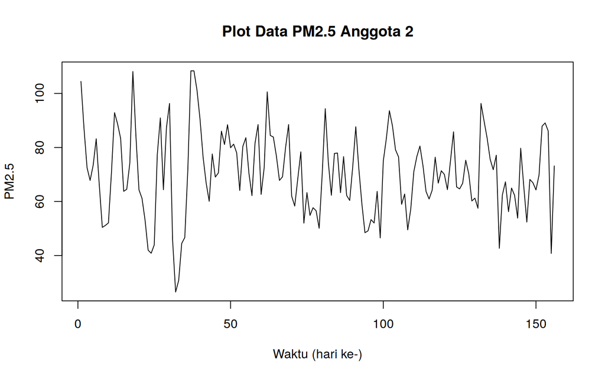

```r
plot.ts(datapm25.ts,
        lty = 1,
        xlab = "Waktu (hari ke-)",
        ylab = "PM2.5",
        main = "Plot Data PM2.5 Anggota 2")
```

Berdasarkan plot data deret waktu, terlihat data bergerak di sekitar nilai tengah tertentu tanpa pola tren yang jelas. Pembagian data latih dan data uji dilakukan dengan proporsi 80:20.

```r
n.train <- floor(0.8 * n)   # 124 data latih
n.test  <- n - n.train      # 32 data uji
c(latih = n.train, uji = n.test)
```

```
## latih   uji
##   124    32
```

## Plot Data Latih

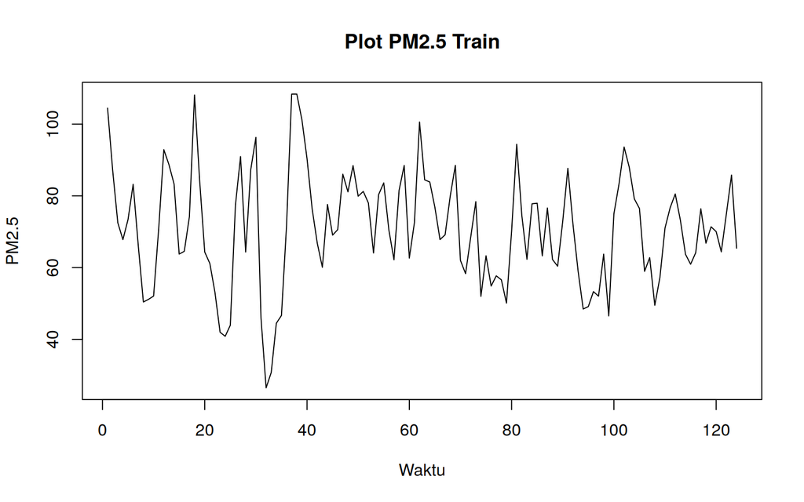

```r
pm25.train <- datapm25[1:n.train]
train.ts <- ts(pm25.train)
plot.ts(train.ts, lty = 1, xlab = "Waktu", ylab = "PM2.5",
        main = "Plot PM2.5 Train")
```

## Plot Data Uji

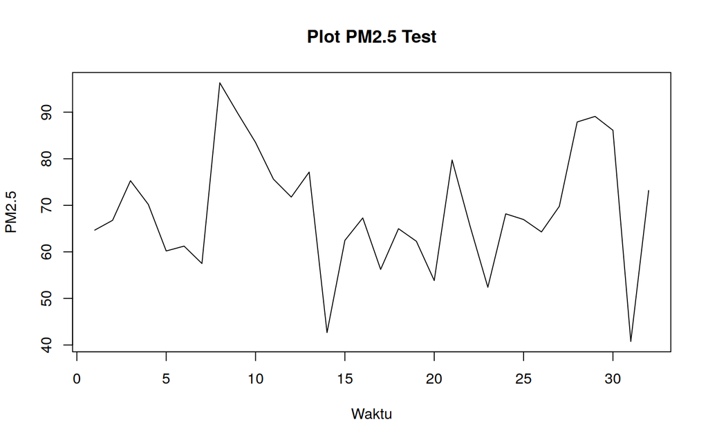

```r
pm25.test <- datapm25[(n.train + 1):n]
test.ts <- ts(pm25.test)
plot.ts(test.ts, lty = 1, xlab = "Waktu", ylab = "PM2.5",
        main = "Plot PM2.5 Test")
```

# Uji Stasioneritas Data

## Plot ACF

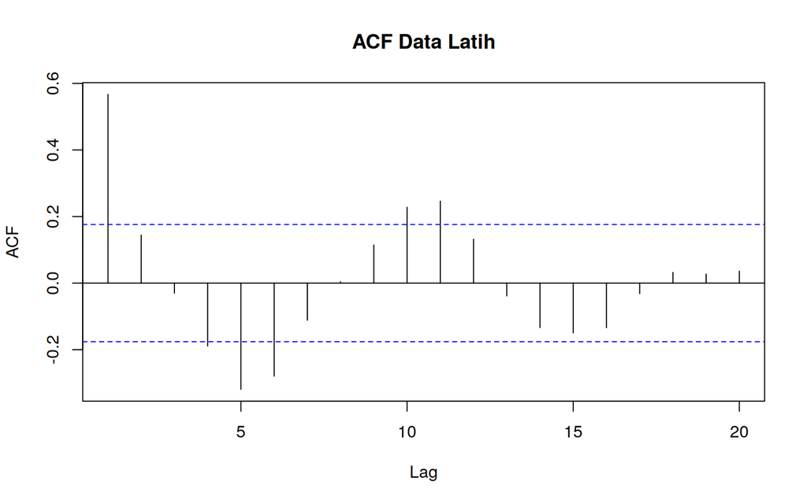

```r
acf(train.ts, main = "ACF Data Latih", lag.max = 20)
```

## Uji ADF

```r
adf.res <- tseries::adf.test(train.ts)
adf.res
```

```
##
##  Augmented Dickey-Fuller Test
##
## data:  train.ts
## Dickey-Fuller = -6.21, Lag order = 4, p-value = 0.01
## alternative hypothesis: stationary
```

$H_0$ : Data tidak stasioner dalam rataan $H_1$ : Data stasioner dalam rataan

Berdasarkan uji ADF tersebut, didapat p-value sebesar 0,01 (lebih kecil dari taraf nyata 5%) sehingga tolak $H_0$ dan menandakan bahwa data stasioner dalam rataan. Dengan demikian, tidak diperlukan differencing dan pemodelan dapat langsung dilakukan dengan $d = 0$.

## Plot Box-Cox

```r
index <- seq(1:n.train)

# Box-Cox
bc <- boxcox(train.ts ~ index, lambda = seq(-2, 2, by = 0.1))
```

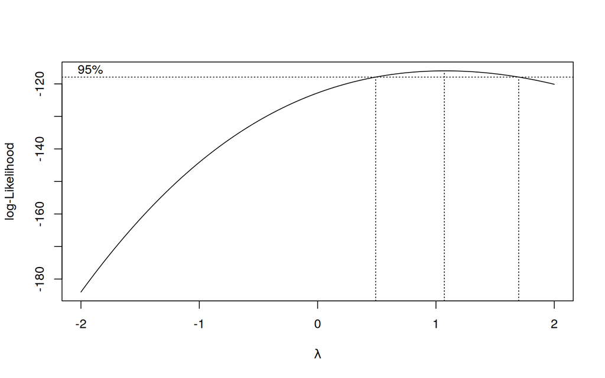

```r
# Nilai lambda optimum
lambda_opt <- bc$x[which.max(bc$y)]
lambda_opt
```

```
## [1] 1.070707
```

```r
# Selang kepercayaan 95% untuk lambda
ci_lambda <- bc$x[bc$y > max(bc$y) - 0.5 * qchisq(0.95, df = 1)]

# Batas bawah dan batas atas
ci_lower <- min(ci_lambda)
ci_upper <- max(ci_lambda)

c(Batas_Bawah = ci_lower, Batas_Atas = ci_upper)
```

```
## Batas_Bawah  Batas_Atas
##   0.5050505   1.6767677
```

Nilai $\lambda$ optimum sebesar 1.07 dengan selang kepercayaan 95% dari 0.51 sampai 1.68. Selang tersebut memuat nilai satu sehingga dapat dikatakan bahwa data stasioner dalam ragam dan tidak perlu transformasi.

# Identifikasi Model

## Plot ACF dan PACF

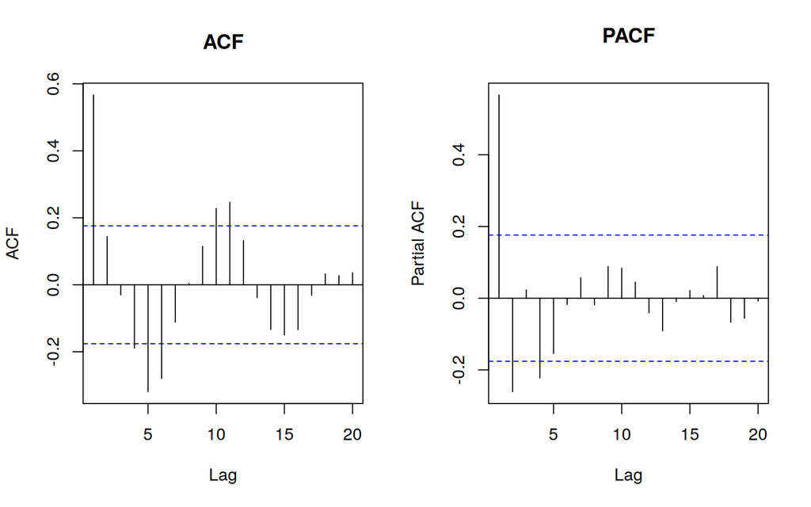

```r
par(mfrow = c(1,2))
acf(train.ts, main = "ACF", lag.max = 20)
pacf(train.ts, main = "PACF", lag.max = 20)
```

```r
par(mfrow = c(1,1))
```

## Plot EACF

```r
eacf(train.ts)
```

```
## AR/MA
##   0 1 2 3 4 5 6 7 8 9 10 11 12 13
## 0 x o o x x x o o o x x  o  o  o
## 1 x x o o x x o o o o o  o  o  o
## 2 o o o o o o o o o o o  o  o  o
## 3 o x o x o o o o o o o  o  o  o
## 4 x x o o x o o o o o o  o  o  o
## 5 o x o o x o o o o o o  o  o  o
## 6 o x o o x o o o o o o  o  o  o
## 7 x x o o x o o o o o o  o  o  o
```

Plot EACF digunakan sebagai pembanding. Segitiga pola nol (“o”) pertama kali muncul secara konsisten pada baris AR=2 mulai MA=0, sehingga EACF juga mengarah pada **ARMA(2,0)** alias ARIMA(2,0,0). Sebagai pembanding, ditambahkan model orde rendah lain yakni ARIMA(1,0,0), ARIMA(0,0,1), ARIMA(4,0,0) (menangkap sinyal PACF di lag 4), dan ARIMA(2,0,1), sehingga terdapat 5 model tentatif.

# Pendugaan Parameter Model Tentatif

```r
# Pendugaan Parameter Model
model1.pm <- Arima(train.ts, order = c(1,0,0), method = "ML")
summary(model1.pm)
```

```
## Series: train.ts
## ARIMA(1,0,0) with non-zero mean
##
## Coefficients:
##          ar1     mean
##       0.5838  71.1458
## s.e.  0.0740   2.7585
##
## sigma^2 = 169.7:  log likelihood = -493.45
## AIC=992.9   AICc=993.1   BIC=1001.36
##
## Training set error measures:
##                      ME     RMSE      MAE       MPE     MAPE     MASE      ACF1
## Training set -0.2074827 12.92041 10.47009 -4.155501 16.06142 0.909315 0.1410553
```

```r
lmtest::coeftest(model1.pm)
```

```
##
## z test of coefficients:
##
##            Estimate Std. Error z value  Pr(>|z|)
## ar1        0.583827   0.074047  7.8846 3.156e-15 ***
## intercept 71.145797   2.758546 25.7911 < 2.2e-16 ***
## ---
## Signif. codes:  0 '***' 0.001 '**' 0.01 '*' 0.05 '.' 0.1 ' ' 1
```

```r
model2.pm <- Arima(train.ts, order = c(2,0,0), method = "ML")
summary(model2.pm)
```

```
## Series: train.ts
## ARIMA(2,0,0) with non-zero mean
##
## Coefficients:
##          ar1      ar2     mean
##       0.7465  -0.2816  70.8984
## s.e.  0.0875   0.0878   2.0782
##
## sigma^2 = 157.8:  log likelihood = -488.52
## AIC=985.05   AICc=985.38   BIC=996.33
##
## Training set error measures:
##                      ME     RMSE      MAE       MPE     MAPE      MASE
## Training set -0.1031478 12.40917 9.989476 -3.710844 15.34068 0.8675739
##                      ACF1
## Training set -0.008020965
```

```r
lmtest::coeftest(model2.pm)
```

```
##
## z test of coefficients:
##
##            Estimate Std. Error z value  Pr(>|z|)
## ar1        0.746549   0.087478  8.5342 < 2.2e-16 ***
## ar2       -0.281630   0.087834 -3.2064  0.001344 **
## intercept 70.898420   2.078160 34.1160 < 2.2e-16 ***
## ---
## Signif. codes:  0 '***' 0.001 '**' 0.01 '*' 0.05 '.' 0.1 ' ' 1
```

```r
model3.pm <- Arima(train.ts, order = c(0,0,1), method = "ML")
summary(model3.pm)
```

```
## Series: train.ts
## ARIMA(0,0,1) with non-zero mean
##
## Coefficients:
##          ma1     mean
##       0.6553  70.8931
## s.e.  0.0609   1.8664
##
## sigma^2 = 161.3:  log likelihood = -490.37
## AIC=986.74   AICc=986.94   BIC=995.2
##
## Training set error measures:
##                       ME     RMSE      MAE       MPE     MAPE      MASE
## Training set -0.08823822 12.59614 10.01613 -4.190006 15.67843 0.8698885
##                   ACF1
## Training set 0.1075369
```

```r
lmtest::coeftest(model3.pm)
```

```
##
## z test of coefficients:
##
##            Estimate Std. Error z value  Pr(>|z|)
## ma1        0.655270   0.060898  10.760 < 2.2e-16 ***
## intercept 70.893083   1.866440  37.983 < 2.2e-16 ***
## ---
## Signif. codes:  0 '***' 0.001 '**' 0.01 '*' 0.05 '.' 0.1 ' ' 1
```

```r
model4.pm <- Arima(train.ts, order = c(4,0,0), method = "ML")
summary(model4.pm)
```

```
## Series: train.ts
## ARIMA(4,0,0) with non-zero mean
##
## Coefficients:
##          ar1      ar2     ar3      ar4     mean
##       0.7625  -0.3761  0.2094  -0.2346  70.8303
## s.e.  0.0886   0.1114  0.1109   0.0883   1.7024
##
## sigma^2 = 151.4:  log likelihood = -485.04
## AIC=982.09   AICc=982.8   BIC=999.01
##
## Training set error measures:
##                       ME     RMSE     MAE       MPE     MAPE     MASE
## Training set -0.05034027 12.05454 9.70397 -3.498499 14.98597 0.842778
##                     ACF1
## Training set -0.04964319
```

```r
lmtest::coeftest(model4.pm)
```

```
##
## z test of coefficients:
##
##            Estimate Std. Error z value  Pr(>|z|)
## ar1        0.762495   0.088561  8.6098 < 2.2e-16 ***
## ar2       -0.376131   0.111433 -3.3754 0.0007371 ***
## ar3        0.209401   0.110882  1.8885 0.0589592 .
## ar4       -0.234583   0.088319 -2.6561 0.0079055 **
## intercept 70.830278   1.702366 41.6070 < 2.2e-16 ***
## ---
## Signif. codes:  0 '***' 0.001 '**' 0.01 '*' 0.05 '.' 0.1 ' ' 1
```

```r
model5.pm <- Arima(train.ts, order = c(2,0,1), method = "ML")
summary(model5.pm)
```

```
## Series: train.ts
## ARIMA(2,0,1) with non-zero mean
##
## Coefficients:
##          ar1      ar2     ma1     mean
##       0.3477  -0.0413  0.4294  70.9535
## s.e.  0.2865   0.2037  0.2751   2.2749
##
## sigma^2 = 157.7:  log likelihood = -487.97
## AIC=985.95   AICc=986.46   BIC=1000.05
##
## Training set error measures:
##                      ME     RMSE      MAE       MPE     MAPE      MASE
## Training set -0.1298017 12.35242 9.949863 -3.737024 15.30839 0.8641335
##                     ACF1
## Training set -0.01768815
```

```r
lmtest::coeftest(model5.pm)
```

```
##
## z test of coefficients:
##
##            Estimate Std. Error z value Pr(>|z|)
## ar1        0.347671   0.286507  1.2135   0.2249
## ar2       -0.041345   0.203705 -0.2030   0.8392
## ma1        0.429442   0.275132  1.5609   0.1186
## intercept 70.953465   2.274924 31.1894   <2e-16 ***
## ---
## Signif. codes:  0 '***' 0.001 '**' 0.01 '*' 0.05 '.' 0.1 ' ' 1
```

# Ringkasan AIC

```r
model_tentatif <- data.frame(
  Model = c("ARIMA(1,0,0)", "ARIMA(2,0,0)", "ARIMA(0,0,1)",
            "ARIMA(4,0,0)", "ARIMA(2,0,1)"),
  AIC = c(AIC(model1.pm), AIC(model2.pm), AIC(model3.pm),
          AIC(model4.pm), AIC(model5.pm)),
  BIC = c(BIC(model1.pm), BIC(model2.pm), BIC(model3.pm),
          BIC(model4.pm), BIC(model5.pm))
)

model_tentatif
```

```
##          Model      AIC       BIC
## 1 ARIMA(1,0,0) 992.8981 1001.3589
## 2 ARIMA(2,0,0) 985.0485  996.3296
## 3 ARIMA(0,0,1) 986.7387  995.1995
## 4 ARIMA(4,0,0) 982.0862  999.0079
## 5 ARIMA(2,0,1) 985.9491 1000.0505
```

# Analisis Sisaan

Model terbaik hasil identifikasi kemudian dicek asumsi sisaannya. Sisaan model ARIMA harus memenuhi asumsi normalitas, kebebasan sisaan, dan kehomogenan ragam. Diagnostik model dilakukan secara eksplorasi dan uji formal.

## Eksplorasi Sisaan

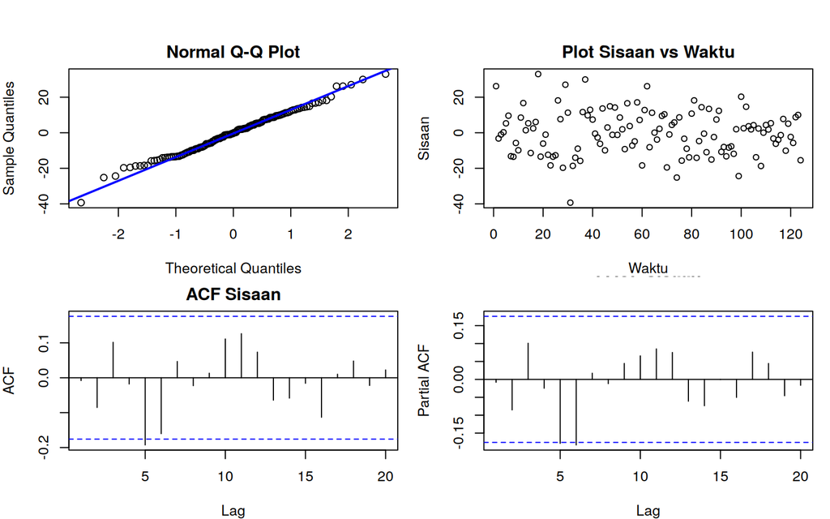

```r
sisaan.pm <- model2.pm$residuals

par(mfrow = c(2,2),
    mar = c(4,4,2,1),
    oma = c(0,0,2,0))

# Q-Q Plot
qqnorm(sisaan.pm, main = "Normal Q-Q Plot")
qqline(sisaan.pm, col = "blue", lwd = 2)

# Plot Sisaan vs Waktu
plot(sisaan.pm, type = "p",
     main = "Plot Sisaan vs Waktu",
     xlab = "Waktu", ylab = "Sisaan")

# ACF
acf(sisaan.pm, main = "ACF Sisaan")

# PACF
pacf(sisaan.pm, main = "PACF Sisaan")
```

```r
par(mfrow = c(1,1))
```

Berdasarkan plot kuantil-kuantil normal, titik-titik sisaan cenderung mengikuti garis $45^{\circ}$ sehingga sisaan secara eksploratif menyebar normal. Plot sisaan terhadap waktu memperlihatkan lebar pita yang cenderung sama sehingga ragam sisaan homogen. Plot ACF dan PACF sisaan tidak menunjukkan *spike* signifikan pada lag-lag awal sehingga sisaan dapat dianggap saling bebas. Kondisi ini akan diuji lebih lanjut dengan uji formal.

## Uji Formal

```r
# Sisaan Menyebar Normal
ks.res <- ks.test(sisaan.pm, "pnorm", mean(sisaan.pm), sd(sisaan.pm))
ks.res
```

```
##
##  Asymptotic one-sample Kolmogorov-Smirnov test
##
## data:  sisaan.pm
## D = 0.036071, p-value = 0.997
## alternative hypothesis: two-sided
```

Pada tahapan ini uji formal yang digunakan untuk normalitas adalah uji Kolmogorov-Smirnov (KS) dengan parameter rataan dan simpangan baku sisaan (karena sisaan tidak berskala N(0,1)). Hipotesisnya sebagai berikut.

$H_0$ : Sisaan menyebar normal $H_1$ : Sisaan tidak menyebar normal

Berdasarkan uji KS tersebut, didapat p-value sebesar 0.997 yang lebih besar dari taraf nyata 5% sehingga gagal tolak $H_0$ dan menandakan bahwa sisaan menyebar normal.

```r
# Sisaan saling bebas/tidak ada autokorelasi
lb.res <- Box.test(sisaan.pm, type = "Ljung")
lb.res
```

```
##
##  Box-Ljung test
##
## data:  sisaan.pm
## X-squared = 0.0081722, df = 1, p-value = 0.928
```

$H_0$ : Sisaan saling bebas $H_1$ : Sisaan tidak saling bebas

Berdasarkan uji Ljung-Box tersebut, didapat p-value sebesar 0.928 yang lebih besar dari taraf nyata 5% sehingga gagal tolak $H_0$ dan menandakan bahwa sisaan saling bebas.

```r
# Sisaan homogen
lb2.res <- Box.test((sisaan.pm)^2, type = "Ljung")
lb2.res
```

```
##
##  Box-Ljung test
##
## data:  (sisaan.pm)^2
## X-squared = 0.25984, df = 1, p-value = 0.6102
```

$H_0$ : Ragam sisaan homogen $H_1$ : Ragam sisaan tidak homogen

Berdasarkan uji Ljung-Box terhadap sisaan kuadrat tersebut, didapat p-value sebesar 0.6102 yang lebih besar dari taraf nyata 5% sehingga gagal tolak $H_0$ dan menandakan bahwa ragam sisaan homogen.

```r
# Nilai tengah sisaan sama dengan nol
t.res <- t.test(sisaan.pm, mu = 0, conf.level = 0.95)
t.res
```

```
##
##  One Sample t-test
##
## data:  sisaan.pm
## t = -0.09219, df = 123, p-value = 0.9267
## alternative hypothesis: true mean is not equal to 0
## 95 percent confidence interval:
##  -2.317859  2.111564
## sample estimates:
##  mean of x
## -0.1031478
```

$H_0$ : nilai tengah sisaan sama dengan 0 $H_1$ : nilai tengah sisaan tidak sama dengan 0

Berdasarkan uji-t tersebut, didapat *p-value* sebesar 0.9267 yang lebih besar dari taraf nyata 5% sehingga gagal tolak $H_0$ dan menandakan bahwa nilai tengah sisaan sama dengan nol. Seluruh uji formal terpenuhi, sehingga model ARIMA(2,0,0) layak digunakan untuk peramalan.

## Overfitting

Tahapan selanjutnya adalah *overfitting*, yaitu menaikkan orde AR(p) dan MA(q) dari model ARIMA(2,0,0) untuk melihat apakah ada model yang lebih baik. Kandidat model *overfitting* adalah ARIMA(3,0,0) dan ARIMA(2,0,1).

```r
model2a.pm <- Arima(train.ts, order = c(3,0,0), method = "ML")
summary(model2a.pm)
```

```
## Series: train.ts
## ARIMA(3,0,0) with non-zero mean
##
## Coefficients:
##          ar1      ar2     ar3     mean
##       0.7558  -0.3061  0.0327  70.9150
## s.e.  0.0911   0.1111  0.0913   2.1458
##
## sigma^2 = 159:  log likelihood = -488.46
## AIC=986.92   AICc=987.43   BIC=1001.02
##
## Training set error measures:
##                      ME     RMSE      MAE       MPE     MAPE      MASE
## Training set -0.1123317 12.40257 10.00572 -3.722406 15.36578 0.8689843
##                      ACF1
## Training set -0.009371187
```

```r
lmtest::coeftest(model2a.pm)   # ar3 tidak signifikan
```

```
##
## z test of coefficients:
##
##            Estimate Std. Error z value  Pr(>|z|)
## ar1        0.755753   0.091111  8.2948 < 2.2e-16 ***
## ar2       -0.306051   0.111105 -2.7546  0.005876 **
## ar3        0.032740   0.091285  0.3587  0.719849
## intercept 70.915021   2.145839 33.0477 < 2.2e-16 ***
## ---
## Signif. codes:  0 '***' 0.001 '**' 0.01 '*' 0.05 '.' 0.1 ' ' 1
```

```r
model2b.pm <- model5.pm  # ARIMA(2,0,1), sudah diduga di atas
summary(model2b.pm)
```

```
## Series: train.ts
## ARIMA(2,0,1) with non-zero mean
##
## Coefficients:
##          ar1      ar2     ma1     mean
##       0.3477  -0.0413  0.4294  70.9535
## s.e.  0.2865   0.2037  0.2751   2.2749
##
## sigma^2 = 157.7:  log likelihood = -487.97
## AIC=985.95   AICc=986.46   BIC=1000.05
##
## Training set error measures:
##                      ME     RMSE      MAE       MPE     MAPE      MASE
## Training set -0.1298017 12.35242 9.949863 -3.737024 15.30839 0.8641335
##                     ACF1
## Training set -0.01768815
```

```r
lmtest::coeftest(model2b.pm)   # ar1, ar2, ma1 tidak signifikan
```

```
##
## z test of coefficients:
##
##            Estimate Std. Error z value Pr(>|z|)
## ar1        0.347671   0.286507  1.2135   0.2249
## ar2       -0.041345   0.203705 -0.2030   0.8392
## ma1        0.429442   0.275132  1.5609   0.1186
## intercept 70.953465   2.274924 31.1894   <2e-16 ***
## ---
## Signif. codes:  0 '***' 0.001 '**' 0.01 '*' 0.05 '.' 0.1 ' ' 1
```

```r
overfitting <- data.frame(
  Model = c("ARIMA(2,0,0)", "ARIMA(3,0,0)", "ARIMA(2,0,1)"),
  AIC   = c(AIC(model2.pm), AIC(model2a.pm), AIC(model2b.pm)),
  BIC   = c(BIC(model2.pm), BIC(model2a.pm), BIC(model2b.pm))
)

overfitting
```

```
##          Model      AIC       BIC
## 1 ARIMA(2,0,0) 985.0485  996.3296
## 2 ARIMA(3,0,0) 986.9199 1001.0213
## 3 ARIMA(2,0,1) 985.9491 1000.0505
```

Kedua model hasil *overfitting* memiliki BIC yang lebih besar dibandingkan ARIMA(2,0,0) dan parameter tambahannya tidak signifikan. Oleh karena itu, model **ARIMA(2,0,0)** tetap digunakan untuk peramalan.

# Model Terbaik : ARIMA(2,0,0)

```r
summary(model2.pm)
```

```
## Series: train.ts
## ARIMA(2,0,0) with non-zero mean
##
## Coefficients:
##          ar1      ar2     mean
##       0.7465  -0.2816  70.8984
## s.e.  0.0875   0.0878   2.0782
##
## sigma^2 = 157.8:  log likelihood = -488.52
## AIC=985.05   AICc=985.38   BIC=996.33
##
## Training set error measures:
##                      ME     RMSE      MAE       MPE     MAPE      MASE
## Training set -0.1031478 12.40917 9.989476 -3.710844 15.34068 0.8675739
##                      ACF1
## Training set -0.008020965
```

```r
lmtest::coeftest(model2.pm)
```

```
##
## z test of coefficients:
##
##            Estimate Std. Error z value  Pr(>|z|)
## ar1        0.746549   0.087478  8.5342 < 2.2e-16 ***
## ar2       -0.281630   0.087834 -3.2064  0.001344 **
## intercept 70.898420   2.078160 34.1160 < 2.2e-16 ***
## ---
## Signif. codes:  0 '***' 0.001 '**' 0.01 '*' 0.05 '.' 0.1 ' ' 1
```

# Peramalan

Peramalan dilakukan menggunakan fungsi `forecast()` sepanjang data uji, yaitu 32 hari ke depan. Karena data sudah stasioner (tanpa differencing), hasil ramalan langsung dibandingkan dengan data uji tanpa *inverse differencing*.

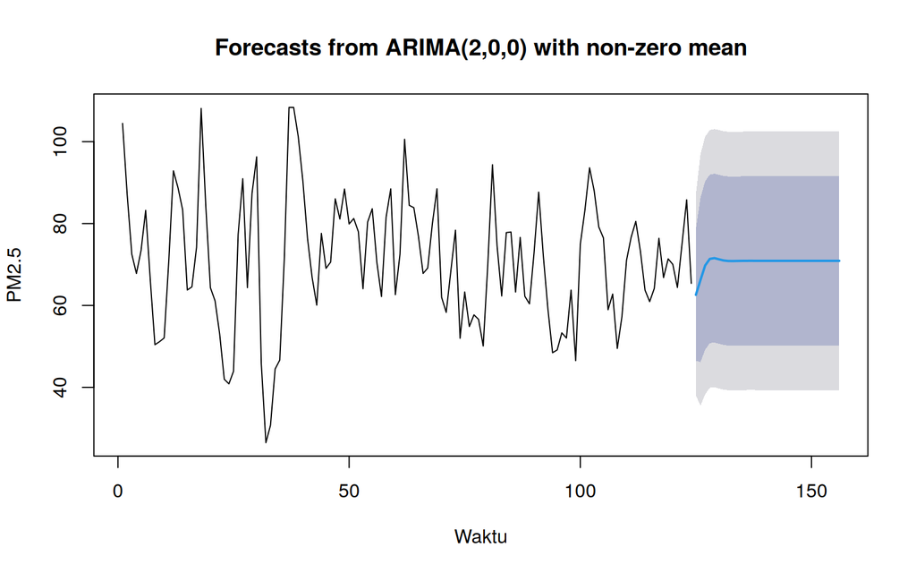

```r
# Forecast
ramalan.pm <- forecast::forecast(model2.pm, h = n.test)
data.ramalan.pm <- as.numeric(ramalan.pm$mean)
plot(ramalan.pm, xlab = "Waktu", ylab = "PM2.5")
```

```r
# Bandingkan aktual vs forecast
perbandingan.pm <- cbind(
  Aktual   = as.numeric(test.ts),
  Forecast = data.ramalan.pm
)
perbandingan.pm
```

```
##        Aktual Forecast
##  [1,] 64.6708 62.59371
##  [2,] 66.7792 66.24825
##  [3,] 75.2833 69.76569
##  [4,] 70.1875 71.36241
##  [5,] 60.1958 71.56382
##  [6,] 61.2375 71.26450
##  [7,] 57.5000 70.98432
##  [8,] 96.3000 70.85945
##  [9,] 89.7833 70.84513
## [10,] 83.4917 70.86961
## [11,] 75.6208 70.89192
## [12,] 71.7708 70.90168
## [13,] 77.1333 70.90268
## [14,] 42.6667 70.90069
```

[output cut: 18 more lines]

```r
# Hitung akurasi
akurasi_test <- accuracy(data.ramalan.pm, as.numeric(test.ts))
akurasi_test
```

```
##                 ME     RMSE      MAE       MPE     MAPE
## Test set -1.639727 13.05377 10.29366 -6.378864 16.44862
```

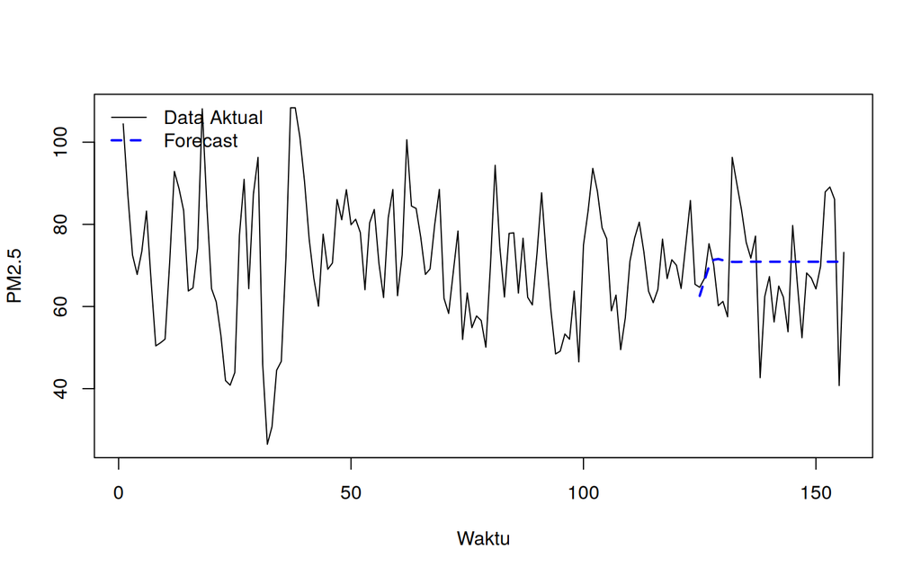

```r
# Plot data aktual vs forecast
ts.plot(datapm25.ts, col = "black", lty = 1,
        xlab = "Waktu", ylab = "PM2.5")

lines((n.train + 1):n, data.ramalan.pm, col = "blue", lty = 2, lwd = 2)
legend("topleft",
       legend = c("Data Aktual", "Forecast"),
       col = c("black", "blue"),
       lty = c(1, 2), lwd = c(1, 2), bty = "n")
```

Hasil ramalan ARIMA(2,0,0) cenderung mendatar mendekati rata-rata data latih (sekitar 70,9) setelah beberapa periode awal. Hal ini wajar karena model AR(2) dengan komponen autoregresif yang meluruh cukup cepat hanya menangkap ketergantungan jangka pendek, sehingga tidak mampu mengikuti fluktuasi harian data uji yang cukup liar (MAPE sekitar 16,4%).